# Harvardx Machine Learning

Comprehension Check: Distance Q1 1/1 point (graded) Load the following dataset:

```r
library(dslabs)
data("tissue_gene_expression")

dim(tissue_gene_expression$x)
```

```
## [1] 189 500
```

```r
table(tissue_gene_expression$y)
```

```
##
##  cerebellum       colon endometrium hippocampus      kidney       liver
##          38          34          15          31          39          26
##    placenta
##           6
```

This matrix has the gene expression levels of 500 genes from 189 biological samples representing seven different tissues. The tissue type is stored in y: Which of the following lines of code computes the Euclidean distance between each observation and stores it in the object d?

```r
d <- dist(tissue_gene_expression$x)
head(d)
```

```
## [1] 7.005922 6.635272 7.331041 5.191081 6.314908 6.568495
```

Q2 1/1 point (graded) Compare the distances between observations 1 and 2 (both cerebellum), observations 39 and 40 (both colon), and observations 73 and 74 (both endometrium). Answer Yes, the samples from the same tissue type are closest to each other. correct

Q3 1/1 point (graded) Make a plot of all the distances using the image function to see if the pattern you observed in Q2 is general. Which code would correctly make the desired plot?

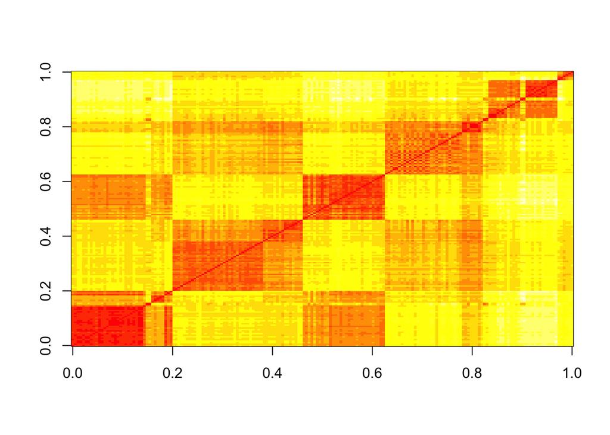

```r
image(as.matrix(d))
```

```r
ind <- c(1, 2, 39, 40, 73, 74)
as.matrix(d)[ind,ind]
```

```
##               cerebellum_1 cerebellum_2   colon_1   colon_2 endometrium_1
## cerebellum_1      0.000000     7.005922 22.694801 22.699755      21.12763
## cerebellum_2      7.005922     0.000000 22.384821 22.069557      20.87910
## colon_1          22.694801    22.384821  0.000000  8.191935      14.99672
## colon_2          22.699755    22.069557  8.191935  0.000000      14.80355
## endometrium_1    21.127629    20.879099 14.996715 14.803545       0.00000
## endometrium_2    21.780792    20.674802 18.089213 17.004456      14.29405
##               endometrium_2
## cerebellum_1       21.78079
## cerebellum_2       20.67480
## colon_1            18.08921
## colon_2            17.00446
## endometrium_1      14.29405
## endometrium_2       0.00000
```

# KNN

```r
library(caret)
library(dslabs)
fit_glm <- glm(y~x_1 + x_2, data=mnist_27$train, family = "binomial")
p_hat_logistic <- predict(fit_glm,mnist_27$test)
y_hat_logistic <- factor(ifelse(p_hat_logistic > 0.5, 7, 2))
#confusionMatrix(data = y_hat_logistic, reference = mnist_27$test$y)$overall[1]

knn_fit <- knn3(y~.,data=mnist_27$train)
knn_fit
```

```
## 5-nearest neighbor model
## Training set outcome distribution:
##
##   2   7
## 379 421
```

Comprehension Check: Nearest Neighbors Q1 2 points possible (graded) Previously, we used logistic regression to predict sex based on height. Now we are going to use knn to do the same. Use the code described in these videos to select the F_1 measure and plot it against k. Compare to the F_1 of about 0.6 we obtained with regression. Set the seed to 1.